# Spotify Music Analysis

Cohen Gress

04/13/2025

## What key audio features distinguish high popularity songs from low popularity songs on Spotify?

### About the datasets:

The project utilizes two distinct datasets sourced from Spotify’s public API, representing songs with high and low popularity scores, respectively. Both datasets contain rich audio features and track metadata, including characteristics like danceability, energy, valence, tempo, and duration. The high popularity dataset includes songs that have performed well on Spotify in terms of streaming and user engagement, providing insight into what attributes may contribute to commercial success. These tracks span multiple decades and originate from Spotify’s global catalog, capturing songs across various genres and countries. The data was compiled and shared publicly via Kaggle by an independent contributor.

The low popularity dataset mirrors the high popularity one in structure and time range, offering a valuable contrast by highlighting tracks that failed to gain widespread attention. By comparing these two datasets, the analysis aims to uncover what differentiates a hit from an overlooked song. Both sources are used together to explore the influence of musical features on popularity, forming the basis for a guiding research question: What makes a song popular on Spotify? This comparison helps identify patterns or features that may be absent in less popular songs and enriches the understanding of success factors in music streaming.

## Key Term Definitions

- **Energy**: A measure from 0.0 to 1.0 describing how energetic a track feels based on features like speed, loudness, and noisiness. Higher energy tracks feel more intense and dynamic.
- **Valence**: A measure from 0.0 to 1.0 describing the musical positiveness conveyed by a track. Higher valence means the track sounds happier or more positive.
- **Danceability**: How suitable a track is for dancing based on tempo, rhythm stability, beat strength, and overall regularity.
- **Loudness**: The overall volume of a track, measured in decibels (dB). Loudness values are typically negative, and higher (less negative) values indicate a louder song.

```r
rm(list = ls())

library(tidyverse)
library(lubridate)
library(ggplot2)
library(readr)
```

```r
# Load high and low popularity datasets
high_pop <- read_csv("high_popularity_spotify_data.csv")
low_pop <- read_csv("low_popularity_spotify_data.csv")
# Add label for group
high_pop <- high_pop %>% mutate(pop_group = "High")
low_pop <- low_pop %>% mutate(pop_group = "Low")

# Combine both datasets
spotify_combined <- bind_rows(high_pop, low_pop)

# Check the structure
str(spotify_combined)
```

```
tibble [4,831 × 30] (S3: tbl_df/tbl/data.frame)
 $ energy                  : num [1:4831] 0.592 0.507 0.808 0.91 0.783 0.582 0.561 0.247 0.416 0.722 ...
 $ tempo                   : num [1:4831] 158 105 109 113 149 ...
 $ danceability            : num [1:4831] 0.521 0.747 0.554 0.67 0.777 0.7 0.669 0.467 0.492 0.769 ...
 $ playlist_genre          : chr [1:4831] "pop" "pop" "pop" "pop" ...
 $ loudness                : num [1:4831] -7.78 -10.17 -4.17 -4.07 -4.48 ...
 $ liveness                : num [1:4831] 0.122 0.117 0.159 0.304 0.355 0.0881 0.0954 0.17 0.203 0.111 ...
 $ valence                 : num [1:4831] 0.535 0.438 0.372 0.786 0.939 0.785 0.841 0.126 0.297 0.57 ...
 $ track_artist            : chr [1:4831] "Lady Gaga, Bruno Mars" "Billie Eilish" "Gracie Abrams" "Sabrina Carpenter" ...
 $ time_signature          : num [1:4831] 3 4 4 4 4 4 4 4 4 4 ...
 $ speechiness             : num [1:4831] 0.0304 0.0358 0.0368 0.0634 0.26 0.0356 0.0411 0.0431 0.0254 0.0507 ...
 $ track_popularity        : num [1:4831] 100 97 93 81 98 94 88 93 71 92 ...
 $ track_href              : chr [1:4831] "https://api.spotify.com/v1/tracks/2plbrEY59IikOBgBGLjaoe" "https://api.spotify.com/v1/tracks/6dOtVTDdiauQNBQEDOtlAB" "https://api.spotify.com/v1/tracks/7ne4VBA60CxGM75vw0EYad" "https://api.spotify.com/v1/tracks/1d7Ptw3qYcfpdLNL5REhtJ" ...
 $ uri                     : chr [1:4831] "spotify:track:2plbrEY59IikOBgBGLjaoe" "spotify:track:6dOtVTDdiauQNBQEDOtlAB" "spotify:track:7ne4VBA60CxGM75vw0EYad" "spotify:track:1d7Ptw3qYcfpdLNL5REhtJ" ...
 $ track_album_name        : chr [1:4831] "Die With A Smile" "HIT ME HARD AND SOFT" "The Secret of Us (Deluxe)" "Short n' Sweet" ...
```

[output cut: 16 more lines]

```r
# Preview high popularity dataset
head(high_pop)
```

| energy | tempo | danceability | playlist_genre | loudness | liveness | valence | track_artist | time_signature | speechiness | track_popularity | track_href | uri | track_album_name | playlist_name | analysis_url | track_id | track_name | track_album_release_date | instrumentalness | track_album_id | mode | key | duration_ms | acousticness | id | playlist_subgenre | type | playlist_id | pop_group |
| --- | --- | --- | --- | --- | --- | --- | --- | --- | --- | --- | --- | --- | --- | --- | --- | --- | --- | --- | --- | --- | --- | --- | --- | --- | --- | --- | --- | --- | --- |
| 0.592 | 157.969 | 0.521 | pop | -7.777 | 0.1220 | 0.535 | Lady Gaga, Bruno Mars | 3 | 0.0304 | 100 | https://api.spotify.com/v1/tracks/2plbrEY59IikOBgBGLjaoe | spotify:track:2plbrEY59IikOBgBGLjaoe | Die With A Smile | Today's Top Hits | https://api.spotify.com/v1/audio-analysis/2plbrEY59IikOBgBGLjaoe | 2plbrEY59IikOBgBGLjaoe | Die With A Smile | 2024-08-16 | 0.0000 | 10FLjwfpbxLmW8c25Xyc2N | 0 | 6 | 251668 | 0.3080 | 2plbrEY59IikOBgBGLjaoe | mainstream | audio_features | 37i9dQZF1DXcBWIGoYBM5M | High |
| 0.507 | 104.978 | 0.747 | pop | -10.171 | 0.1170 | 0.438 | Billie Eilish | 4 | 0.0358 | 97 | https://api.spotify.com/v1/tracks/6dOtVTDdiauQNBQEDOtlAB | spotify:track:6dOtVTDdiauQNBQEDOtlAB | HIT ME HARD AND SOFT | Today's Top Hits | https://api.spotify.com/v1/audio-analysis/6dOtVTDdiauQNBQEDOtlAB | 6dOtVTDdiauQNBQEDOtlAB | BIRDS OF A FEATHER | 2024-05-17 | 0.0608 | 7aJuG4TFXa2hmE4z1yxc3n | 1 | 2 | 210373 | 0.2000 | 6dOtVTDdiauQNBQEDOtlAB | mainstream | audio_features | 37i9dQZF1DXcBWIGoYBM5M | High |
| 0.808 | 108.548 | 0.554 | pop | -4.169 | 0.1590 | 0.372 | Gracie Abrams | 4 | 0.0368 | 93 | https://api.spotify.com/v1/tracks/7ne4VBA60CxGM75vw0EYad | spotify:track:7ne4VBA60CxGM75vw0EYad | The Secret of Us (Deluxe) | Today's Top Hits | https://api.spotify.com/v1/audio-analysis/7ne4VBA60CxGM75vw0EYad | 7ne4VBA60CxGM75vw0EYad | That’s So True | 2024-10-18 | 0.0000 | 0hBRqPYPXhr1RkTDG3n4Mk | 1 | 1 | 166300 | 0.2140 | 7ne4VBA60CxGM75vw0EYad | mainstream | audio_features | 37i9dQZF1DXcBWIGoYBM5M | High |
| 0.910 | 112.966 | 0.670 | pop | -4.070 | 0.3040 | 0.786 | Sabrina Carpenter | 4 | 0.0634 | 81 | https://api.spotify.com/v1/tracks/1d7Ptw3qYcfpdLNL5REhtJ | spotify:track:1d7Ptw3qYcfpdLNL5REhtJ | Short n' Sweet | Today's Top Hits | https://api.spotify.com/v1/audio-analysis/1d7Ptw3qYcfpdLNL5REhtJ | 1d7Ptw3qYcfpdLNL5REhtJ | Taste | 2024-08-23 | 0.0000 | 4B4Elma4nNDUyl6D5PvQkj | 0 | 0 | 157280 | 0.0939 | 1d7Ptw3qYcfpdLNL5REhtJ | mainstream | audio_features | 37i9dQZF1DXcBWIGoYBM5M | High |
| 0.783 | 149.027 | 0.777 | pop | -4.477 | 0.3550 | 0.939 | ROSÉ, Bruno Mars | 4 | 0.2600 | 98 | https://api.spotify.com/v1/tracks/5vNRhkKd0yEAg8suGBpjeY | spotify:track:5vNRhkKd0yEAg8suGBpjeY | APT. | Today's Top Hits | https://api.spotify.com/v1/audio-analysis/5vNRhkKd0yEAg8suGBpjeY | 5vNRhkKd0yEAg8suGBpjeY | APT. | 2024-10-18 | 0.0000 | 2IYQwwgxgOIn7t3iF6ufFD | 0 | 0 | 169917 | 0.0283 | 5vNRhkKd0yEAg8suGBpjeY | mainstream | audio_features | 37i9dQZF1DXcBWIGoYBM5M | High |
| 0.582 | 116.712 | 0.700 | pop | -5.960 | 0.0881 | 0.785 | Chappell Roan | 4 | 0.0356 | 94 | https://api.spotify.com/v1/tracks/0WbMK4wrZ1wFSty9F7FCgu | spotify:track:0WbMK4wrZ1wFSty9F7FCgu | Good Luck, Babe! | Today's Top Hits | https://api.spotify.com/v1/audio-analysis/0WbMK4wrZ1wFSty9F7FCgu | 0WbMK4wrZ1wFSty9F7FCgu | Good Luck, Babe! | 2024-04-05 | 0.0000 | 1WAjjRMfZjEXtB0lQrAw6Q | 0 | 11 | 218424 | 0.0502 | 0WbMK4wrZ1wFSty9F7FCgu | mainstream | audio_features | 37i9dQZF1DXcBWIGoYBM5M | High |

```r
# Preview low popularity dataset
head(low_pop)
```

| time_signature | track_popularity | speechiness | danceability | playlist_name | track_artist | duration_ms | energy | playlist_genre | playlist_subgenre | track_href | track_name | mode | uri | type | track_album_release_date | analysis_url | id | instrumentalness | track_album_id | playlist_id | track_id | valence | key | tempo | loudness | acousticness | liveness | track_album_name | pop_group |
| --- | --- | --- | --- | --- | --- | --- | --- | --- | --- | --- | --- | --- | --- | --- | --- | --- | --- | --- | --- | --- | --- | --- | --- | --- | --- | --- | --- | --- | --- |
| 4 | 23 | 0.0393 | 0.636 | Rock Classics | Creedence Clearwater Revival | 138053 | 0.746 | rock | classic | https://api.spotify.com/v1/tracks/5e6x5YRnMJIKvYpZxLqdpH | Fortunate Son | 1 | spotify:track:5e6x5YRnMJIKvYpZxLqdpH | audio_features | 2005-12-14 | https://api.spotify.com/v1/audio-analysis/5e6x5YRnMJIKvYpZxLqdpH | 5e6x5YRnMJIKvYpZxLqdpH | 2.90e-01 | 4A8gFwqd9jTtnsNwUu3OQx | 37i9dQZF1DWXRqgorJj26U | 5e6x5YRnMJIKvYpZxLqdpH | 0.432 | 0 | 132.310 | -3.785 | 0.0648 | 0.1730 | The Long Road Home - The Ultimate John Fogerty / Creedence Collection | Low |
| 4 | 53 | 0.0317 | 0.572 | Rock Classics | Van Halen | 241600 | 0.835 | rock | classic | https://api.spotify.com/v1/tracks/5FqYA8KfiwsQvyBI4IamnY | Jump - 2015 Remaster | 1 | spotify:track:5FqYA8KfiwsQvyBI4IamnY | audio_features | 2015-03-27 | https://api.spotify.com/v1/audio-analysis/5FqYA8KfiwsQvyBI4IamnY | 5FqYA8KfiwsQvyBI4IamnY | 3.77e-04 | 2c965LEDRNrXXCeBOAAwns | 37i9dQZF1DWXRqgorJj26U | 5FqYA8KfiwsQvyBI4IamnY | 0.795 | 0 | 129.981 | -6.219 | 0.1710 | 0.0702 | The Collection | Low |
| 4 | 55 | 0.0454 | 0.591 | Rock Classics | Stevie Nicks | 329413 | 0.804 | rock | classic | https://api.spotify.com/v1/tracks/5LNiqEqpDc8TuqPy79kDBu | Edge of Seventeen - 2016 Remaster | 1 | spotify:track:5LNiqEqpDc8TuqPy79kDBu | audio_features | 2016-11-04 | https://api.spotify.com/v1/audio-analysis/5LNiqEqpDc8TuqPy79kDBu | 5LNiqEqpDc8TuqPy79kDBu | 5.98e-06 | 3S404OgKoVQSJ3xXrDVlp8 | 37i9dQZF1DWXRqgorJj26U | 5LNiqEqpDc8TuqPy79kDBu | 0.658 | 0 | 111.457 | -7.299 | 0.3270 | 0.0818 | Bella Donna (Deluxe Edition) | Low |
| 4 | 64 | 0.1010 | 0.443 | Jazz Classics | Ella Fitzgerald, Louis Armstrong | 185160 | 0.104 | jazz | classic | https://api.spotify.com/v1/tracks/78MI7mu1LV1k4IA2HzKmHe | Dream A Little Dream Of Me - Single Version | 1 | spotify:track:78MI7mu1LV1k4IA2HzKmHe | audio_features | 2007-05-03 | https://api.spotify.com/v1/audio-analysis/78MI7mu1LV1k4IA2HzKmHe | 78MI7mu1LV1k4IA2HzKmHe | 0.00e+00 | 1y5KGkUKO0NG32MhIIagCA | 37i9dQZF1DXbITWG1ZJKYt | 78MI7mu1LV1k4IA2HzKmHe | 0.394 | 0 | 76.474 | -17.042 | 0.9130 | 0.1910 | Love, Ella | Low |
| 4 | 62 | 0.0298 | 0.685 | Jazz Classics | Galt MacDermot | 205720 | 0.472 | jazz | classic | https://api.spotify.com/v1/tracks/6MN6yRVriszuyAVlyF8ndB | Coffee Cold | 0 | spotify:track:6MN6yRVriszuyAVlyF8ndB | audio_features | 2000-01-01 | https://api.spotify.com/v1/audio-analysis/6MN6yRVriszuyAVlyF8ndB | 6MN6yRVriszuyAVlyF8ndB | 2.84e-01 | 6f4b9wVTkKAf096k4XG6x5 | 37i9dQZF1DXbITWG1ZJKYt | 6MN6yRVriszuyAVlyF8ndB | 0.475 | 9 | 80.487 | -9.691 | 0.7850 | 0.2240 | Shapes of Rhythm/Woman Is Sweeter | Low |
| 4 | 61 | 0.0566 | 0.670 | Jazz Classics | Frank Sinatra, Count Basie | 147147 | 0.365 | jazz | classic | https://api.spotify.com/v1/tracks/2dR5WkrpwylTuT3jRWNufa | Fly Me To The Moon | 1 | spotify:track:2dR5WkrpwylTuT3jRWNufa | audio_features | 2015-04-17 | https://api.spotify.com/v1/audio-analysis/2dR5WkrpwylTuT3jRWNufa | 2dR5WkrpwylTuT3jRWNufa | 0.00e+00 | 7gmak9ZGm10y4PtZa9SBQn | 37i9dQZF1DXbITWG1ZJKYt | 2dR5WkrpwylTuT3jRWNufa | 0.450 | 0 | 119.347 | -10.158 | 0.5250 | 0.0575 | Ultimate Sinatra | Low |

```r
NA
```

```r
# Using regular expressions to find songs with "love" in the track name
love_songs <- spotify_combined %>%
  filter(str_detect(track_name, regex("love", ignore_case = TRUE)))

# Preview love songs
head(love_songs)
```

| energy | tempo | danceability | playlist_genre | loudness | liveness | valence | track_artist | time_signature | speechiness | track_popularity | track_href | uri | track_album_name | playlist_name | analysis_url | track_id | track_name | track_album_release_date | instrumentalness | track_album_id | mode | key | duration_ms | acousticness | id | playlist_subgenre | type | playlist_id | pop_group |
| --- | --- | --- | --- | --- | --- | --- | --- | --- | --- | --- | --- | --- | --- | --- | --- | --- | --- | --- | --- | --- | --- | --- | --- | --- | --- | --- | --- | --- | --- |
| 0.843 | 122.064 | 0.619 | pop | -5.348 | 0.164 | 0.746 | Morgan Wallen | 4 | 0.0284 | 86 | https://api.spotify.com/v1/tracks/7hR22TOX3RorxJPcsz5Wbo | spotify:track:7hR22TOX3RorxJPcsz5Wbo | Love Somebody | Today's Top Hits | https://api.spotify.com/v1/audio-analysis/7hR22TOX3RorxJPcsz5Wbo | 7hR22TOX3RorxJPcsz5Wbo | Love Somebody | 2024-10-18 | 1.18e-04 | 0TxewlKVKdpP18dGg279ep | 0 | 5 | 204829 | 0.009480 | 7hR22TOX3RorxJPcsz5Wbo | mainstream | audio_features | 37i9dQZF1DXcBWIGoYBM5M | High |
| 0.406 | 115.940 | 0.530 | pop | -7.507 | 0.133 | 0.338 | Gracie Abrams | 3 | 0.0330 | 90 | https://api.spotify.com/v1/tracks/51rfRCiUSvxXlCSCfIztBy | spotify:track:51rfRCiUSvxXlCSCfIztBy | The Secret of Us | Today's Top Hits | https://api.spotify.com/v1/audio-analysis/51rfRCiUSvxXlCSCfIztBy | 51rfRCiUSvxXlCSCfIztBy | I Love You, I'm Sorry | 2024-06-21 | 0.00e+00 | 56bdWeO40o3WfAD2Lja4dl | 1 | 10 | 157147 | 0.656000 | 51rfRCiUSvxXlCSCfIztBy | mainstream | audio_features | 37i9dQZF1DXcBWIGoYBM5M | High |
| 0.646 | 115.842 | 0.645 | pop | -8.334 | 0.074 | 0.295 | Ariana Grande | 4 | 0.0427 | 81 | https://api.spotify.com/v1/tracks/46kspZSY3aKmwQe7O77fCC | spotify:track:46kspZSY3aKmwQe7O77fCC | eternal sunshine | Today's Top Hits | https://api.spotify.com/v1/audio-analysis/46kspZSY3aKmwQe7O77fCC | 46kspZSY3aKmwQe7O77fCC | we can't be friends (wait for your love) | 2024-03-08 | 3.04e-05 | 71PfP4E9roOXAudea1aPGw | 1 | 5 | 228639 | 0.061500 | 46kspZSY3aKmwQe7O77fCC | mainstream | audio_features | 37i9dQZF1DXcBWIGoYBM5M | High |
| 0.716 | 94.379 | 0.535 | rock | -5.025 | 0.659 | 0.901 | Joan Jett & the Blackhearts | 4 | 0.0431 | 77 | https://api.spotify.com/v1/tracks/2Cdvbe2G4hZsnhNMKyGrie | spotify:track:2Cdvbe2G4hZsnhNMKyGrie | I Love Rock 'N' Roll (Expanded Edition) | Rock Classics | https://api.spotify.com/v1/audio-analysis/2Cdvbe2G4hZsnhNMKyGrie | 2Cdvbe2G4hZsnhNMKyGrie | I Love Rock 'N Roll | 1981-11-18 | 0.00e+00 | 555qwe1qUgLdee80TZ2CQt | 1 | 4 | 175173 | 0.326000 | 2Cdvbe2G4hZsnhNMKyGrie | classic | audio_features | 37i9dQZF1DWXRqgorJj26U | High |
| 0.902 | 89.740 | 0.412 | rock | -11.600 | 0.405 | 0.422 | Led Zeppelin | 4 | 0.4050 | 72 | https://api.spotify.com/v1/tracks/0hCB0YR03f6AmQaHbwWDe8 | spotify:track:0hCB0YR03f6AmQaHbwWDe8 | Led Zeppelin II (1994 Remaster) | Rock Classics | https://api.spotify.com/v1/audio-analysis/0hCB0YR03f6AmQaHbwWDe8 | 0hCB0YR03f6AmQaHbwWDe8 | Whole Lotta Love - 1990 Remaster | 1969-10-22 | 1.31e-01 | 70lQYZtypdCALtFVlQAcvx | 1 | 9 | 333893 | 0.048400 | 0hCB0YR03f6AmQaHbwWDe8 | classic | audio_features | 37i9dQZF1DWXRqgorJj26U | High |
| 0.927 | 170.814 | 0.215 | rock | -7.327 | 0.126 | 0.490 | Stone Temple Pilots | 4 | 0.0452 | 72 | https://api.spotify.com/v1/tracks/6qLEOZvf5gI7kWE63JE7p3 | spotify:track:6qLEOZvf5gI7kWE63JE7p3 | Purple (2019 Remaster) | Rock Classics | https://api.spotify.com/v1/audio-analysis/6qLEOZvf5gI7kWE63JE7p3 | 6qLEOZvf5gI7kWE63JE7p3 | Interstate Love Song - 2019 Remaster | 1994-06-07 | 6.61e-03 | 57lcTrUlYgfMIPvBUsVU6h | 1 | 9 | 194853 | 0.000273 | 6qLEOZvf5gI7kWE63JE7p3 | classic | audio_features | 37i9dQZF1DWXRqgorJj26U | High |

```r
NA
```

```r
# Defining a user function that safely handles NA values
classify_energy <- function(energy_value) {
  if (is.na(energy_value)) {
    return(NA)  # keep missing values missing
  } else if (energy_value >= 0.7) {
    return("High Energy")
  } else if (energy_value >= 0.4) {
    return("Medium Energy")
  } else {
    return("Low Energy")
  }
}

# Apply the function to create a new column
spotify_combined <- spotify_combined %>%
  mutate(energy_level = sapply(energy, classify_energy))
```

```r
spotify_combined %>%
  group_by(pop_group) %>%
  summarise(across(c(danceability, energy, valence, tempo, acousticness), list(mean = mean, sd = sd), na.rm = TRUE))
```

| pop_group | danceability_mean | danceability_sd | energy_mean | energy_sd | valence_mean | valence_sd | tempo_mean | tempo_sd | acousticness_mean | acousticness_sd |
| --- | --- | --- | --- | --- | --- | --- | --- | --- | --- | --- |
| High | 0.6503618 | 0.1577215 | 0.6672161 | 0.1849078 | 0.5257365 | 0.2361132 | 121.0709 | 27.06603 | 0.2212195 | 0.2505929 |
| Low | 0.6072684 | 0.2003718 | 0.5435088 | 0.2636350 | 0.4584377 | 0.2661397 | 116.7669 | 29.15240 | 0.4055667 | 0.3422494 |

```r
NA
```

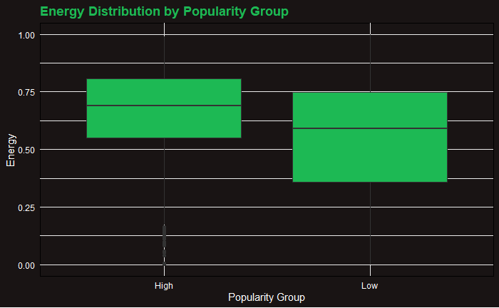

```r
ggplot(spotify_combined, aes(x = pop_group, y = energy, fill = pop_group)) +
  geom_boxplot() +
  scale_fill_manual(values = c("High" = "#1DB954", "Low" = "#1DB954")) +
  labs(title = "Energy Distribution by Popularity Group", x = "Popularity Group", y = "Energy") +
  theme_minimal() +
  theme(
    plot.background = element_rect(fill = "#191414", color = NA),
    panel.background = element_rect(fill = "#191414"),
    legend.position = "none",
    text = element_text(color = "white"),
    axis.text = element_text(color = "white"),
    axis.title = element_text(color = "white"),
    plot.title = element_text(color = "#1DB954", face = "bold")
  )
```

This boxplot compares the energy levels between high and low popularity songs. High popularity tracks tend to have a slightly higher median energy, and the overall distribution is shifted upward compared to low popularity songs. This supports the idea that songs with greater energy are more likely to become popular on Spotify.

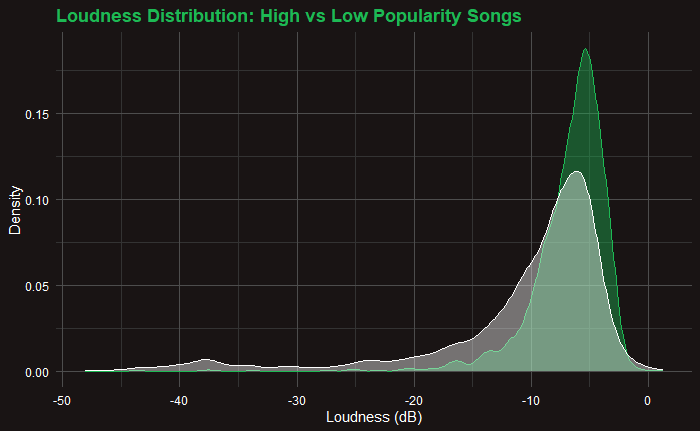

```r
ggplot() +
  geom_density(data = high_pop, aes(x = loudness), color = "#1DB954", fill = "#1DB954", alpha = 0.4) +
  geom_density(data = low_pop, aes(x = loudness), color = "white", fill = "white", alpha = 0.4) +
  labs(title = "Loudness Distribution: High vs Low Popularity Songs",
       x = "Loudness (dB)",
       y = "Density") +
  theme_minimal() +
  theme(
    plot.background = element_rect(fill = "#191414", color = NA),
    panel.background = element_rect(fill = "#191414", color = NA),
    panel.grid.major = element_line(color = "gray30"),
    panel.grid.minor = element_line(color = "gray20"),
    axis.text = element_text(color = "white"),
    axis.title = element_text(color = "white"),
    plot.title = element_text(color = "#1DB954", face = "bold"),
    legend.position = "none"
  )
```

This density plot shows that high popularity songs are generally louder than low popularity songs. The distribution for high popularity tracks is clearly shifted toward higher loudness values, suggesting that louder, more intense audio is associated with better streaming performance.

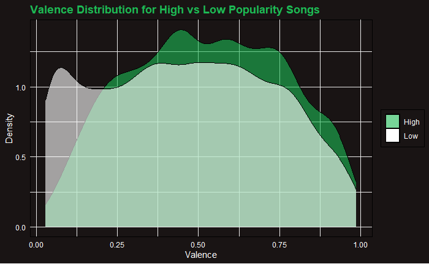

```r
ggplot(spotify_combined, aes(x = valence, fill = pop_group)) +
  geom_density(alpha = 0.6) +
  scale_fill_manual(values = c("High" = "#1DB954", "Low" = "white")) +
  labs(title = "Valence Distribution for High vs Low Popularity Songs",
       x = "Valence", y = "Density") +
  theme_minimal() +
  theme(
    plot.background = element_rect(fill = "#191414", color = NA),
    panel.background = element_rect(fill = "#191414"),
    legend.background = element_rect(fill = "#191414"),
    legend.key = element_rect(fill = "white"),
    legend.title = element_blank(),
    legend.text = element_text(color = "white"),
    text = element_text(color = "white"),
    axis.text = element_text(color = "white"),
    axis.title = element_text(color = "white"),
    plot.title = element_text(color = "#1DB954", face = "bold")
  )
```

This graph compares valence, which measures the emotional positivity of a track, across popularity groups. The distributions overlap more heavily compared to energy and loudness, meaning both happy and sad songs can achieve popularity. However, high popularity songs still show a slight skew toward higher valence, hinting that more positive-sounding tracks may have a small advantage.